# BIOS 611 Final Project

Camille Liu

10/28/2022

## Introduction

The topic of our project is to improve the performance in telemarketing using predictive models. Telemarketing is a method of marketing directly to customers via phone or the Internet in order to sell goods or services. The telemarketing industry has a market size of $23.4 bn in 2022 and is still expecting a 2% growth in market [size](https://www.ibisworld.com/industry-statistics/market-size/telemarketing-call-centers-united-states/). A central challenge in telemarketing is in targeting individuals to sell goods or services. It would be costly to indiscriminately canvas everyone, but it would also be undesirable to target a random subset of the population as many potential sales could be lost. Thus, there is great interest in tools to identify the groups of individuals for whom telemarketing would likely result in sales and the groups of whom telemarketing is unlikely to be successful. Then, the firm could save resources by ignoring those in the latter group while not losing out on potential sales [1].

In this project, we analysed a telemarketing dataset from a Portuguese retail bank [dataset](https://archive.ics.uci.edu/ml/datasets/bank+marketing) [2], which contains information on clients who were contacted by phone call to sell term deposit subscriptions (also known as certificate of deposits) and the outcome of the contact, which is a binary indicator for if the client subscribed a term deposit, which we call a “success”.

Table 1: Description of variables in telemarketing data set

| Feature Name | Description |
| --- | --- |
| age | numeric |
| job | type of job (categorical) |
| marital | marital status (categorical: married, divorced, single) |
| education | (categorical: unknown,secondary, primary, tertiary) |
| default | has credit in default? (binary: yes, no) |
| balance | average yearly balance, in euros (numeric) |
| housing | has housing loan? (binary: yes, no) |
| loan | has personal loan? (binary: yes, no) |
| contact | contact communication type (categorical: unknown, telephone, cellular) |
| day | last contact day of the month (numeric) |
| month | last contact month of year (categorical: jan, feb, mar, …, nov, dec) |
| duration | last contact duration, in seconds (numeric) |
| campaign | number of contacts performed during this campaign and for this client (numeric) |
| pdays | number of days that passed by after last contacted from a previous campaign (numeric) |
| previous | number of contacts performed before this campaign and for this client (numeric) |
| poutcome | outcome of previous campaign (categorical: unknown, other, failure, success) |
| outcome | has the client subscribed a term deposit? (binary: yes, no) |

## Data description and pre-processing

There are four datasets available. We chose the dataset with 16 features and all 45,211 observations (called `bank-full.csv` on the source website). To ease computational burden, we randomly selected 20 percent of the data for our analysis dataset(`dat.working`), which includes 9,042 observations.

The binary outcome variable is highly imbalanced, with 7983 (88%) failures and 1059 (12%) successes.

```r
# combine the labels
q1 <- c('mar','feb','jan')
q2 <- c('apr','may','jun')
q3 <- c('jul','aug','sep')
q4 <- c('nov','oct','dec')

# #collape month into quarters
# dat_full$month<-recode(dat_full$month,
#                        "q1='q1'; q2='q2'; q3 = 'q3'; q4 = 'q4'")

# drop pdays and duration
dat = dat_full %>% select(-pdays, -duration)

# analysis dataset
set.seed(100)
dat.working <- dat %>%
  mutate_if(is.character, as.factor) %>% # convert character to factor
  slice_sample(prop = 0.2) # select subset
```

```r
table1(~.|y, data = dat.working,
       caption = 'Table 2: Summary of features, by observed success/failure')
```

Table 2: Summary of features, by observed success/failure

|  | no (N=7983) | yes (N=1059) | Overall (N=9042) |
| --- | --- | --- | --- |
| age |  |  |  |
| Mean (SD) | 40.8 (10.2) | 41.5 (13.5) | 40.9 (10.6) |
| Median [Min, Max] | 39.0 [18.0, 89.0] | 38.0 [19.0, 92.0] | 39.0 [18.0, 92.0] |
| job |  |  |  |
| admin. | 916 (11.5%) | 118 (11.1%) | 1034 (11.4%) |
| blue-collar | 1825 (22.9%) | 148 (14.0%) | 1973 (21.8%) |
| entrepreneur | 264 (3.3%) | 10 (0.9%) | 274 (3.0%) |
| housemaid | 218 (2.7%) | 24 (2.3%) | 242 (2.7%) |
| management | 1637 (20.5%) | 261 (24.6%) | 1898 (21.0%) |
| retired | 341 (4.3%) | 101 (9.5%) | 442 (4.9%) |
| self-employed | 273 (3.4%) | 33 (3.1%) | 306 (3.4%) |
| services | 754 (9.4%) | 77 (7.3%) | 831 (9.2%) |
| student | 140 (1.8%) | 51 (4.8%) | 191 (2.1%) |
| technician | 1356 (17.0%) | 176 (16.6%) | 1532 (16.9%) |
| unemployed | 208 (2.6%) | 52 (4.9%) | 260 (2.9%) |
| unknown | 51 (0.6%) | 8 (0.8%) | 59 (0.7%) |
| marital |  |  |  |
| divorced | 857 (10.7%) | 133 (12.6%) | 990 (10.9%) |
| married | 4932 (61.8%) | 539 (50.9%) | 5471 (60.5%) |
| single | 2194 (27.5%) | 387 (36.5%) | 2581 (28.5%) |
| education |  |  |  |
| primary | 1234 (15.5%) | 118 (11.1%) | 1352 (15.0%) |
| secondary | 4150 (52.0%) | 483 (45.6%) | 4633 (51.2%) |
| tertiary | 2293 (28.7%) | 409 (38.6%) | 2702 (29.9%) |
| unknown | 306 (3.8%) | 49 (4.6%) | 355 (3.9%) |
| default |  |  |  |
| no | 7836 (98.2%) | 1048 (99.0%) | 8884 (98.3%) |
| yes | 147 (1.8%) | 11 (1.0%) | 158 (1.7%) |
| balance |  |  |  |
| Mean (SD) | 1290 (3030) | 1730 (3380) | 1350 (3080) |
| Median [Min, Max] | 425 [-4060, 98400] | 712 [-1940, 52600] | 453 [-4060, 98400] |
| housing |  |  |  |
| no | 3381 (42.4%) | 674 (63.6%) | 4055 (44.8%) |
| yes | 4602 (57.6%) | 385 (36.4%) | 4987 (55.2%) |
| loan |  |  |  |
| no | 6594 (82.6%) | 967 (91.3%) | 7561 (83.6%) |
| yes | 1389 (17.4%) | 92 (8.7%) | 1481 (16.4%) |
| contact |  |  |  |
| cellular | 5016 (62.8%) | 878 (82.9%) | 5894 (65.2%) |
| telephone | 502 (6.3%) | 78 (7.4%) | 580 (6.4%) |
| unknown | 2465 (30.9%) | 103 (9.7%) | 2568 (28.4%) |
| day |  |  |  |
| Mean (SD) | 16.0 (8.29) | 15.2 (8.35) | 15.9 (8.30) |
| Median [Min, Max] | 16.0 [1.00, 31.0] | 15.0 [1.00, 31.0] | 16.0 [1.00, 31.0] |
| month |  |  |  |
| apr | 433 (5.4%) | 111 (10.5%) | 544 (6.0%) |
| aug | 1141 (14.3%) | 139 (13.1%) | 1280 (14.2%) |
| dec | 23 (0.3%) | 25 (2.4%) | 48 (0.5%) |
| feb | 452 (5.7%) | 93 (8.8%) | 545 (6.0%) |
| jan | 249 (3.1%) | 27 (2.5%) | 276 (3.1%) |
| jul | 1251 (15.7%) | 135 (12.7%) | 1386 (15.3%) |
| jun | 920 (11.5%) | 117 (11.0%) | 1037 (11.5%) |
| mar | 46 (0.6%) | 56 (5.3%) | 102 (1.1%) |
| may | 2568 (32.2%) | 167 (15.8%) | 2735 (30.2%) |
| nov | 747 (9.4%) | 74 (7.0%) | 821 (9.1%) |
| oct | 88 (1.1%) | 61 (5.8%) | 149 (1.6%) |
| sep | 65 (0.8%) | 54 (5.1%) | 119 (1.3%) |
| campaign |  |  |  |
| Mean (SD) | 2.83 (3.17) | 2.19 (2.03) | 2.76 (3.06) |
| Median [Min, Max] | 2.00 [1.00, 46.0] | 2.00 [1.00, 32.0] | 2.00 [1.00, 46.0] |
| previous |  |  |  |
| Mean (SD) | 0.527 (3.58) | 1.22 (2.56) | 0.607 (3.49) |
| Median [Min, Max] | 0 [0, 275] | 0 [0, 30.0] | 0 [0, 275] |
| poutcome |  |  |  |
| failure | 842 (10.5%) | 114 (10.8%) | 956 (10.6%) |
| other | 302 (3.8%) | 60 (5.7%) | 362 (4.0%) |
| success | 105 (1.3%) | 199 (18.8%) | 304 (3.4%) |
| unknown | 6734 (84.4%) | 686 (64.8%) | 7420 (82.1%) |

Figures 1-4 show some insights from the data. Figure 1 shows a density plot of age by subscription status. Most individuals in the data are between 25 and 60 years old. Additionally, relatively more individuals subcribed than not at the extremes of the age distribution.

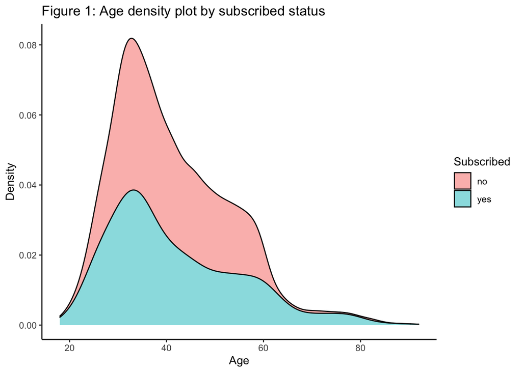

```r
ggplot(dat.working, aes(x = age, fill = y)) +
  geom_density(alpha = 0.5,position = 'stack') +
  theme_classic() +
  labs(title = 'Figure 1: Age density plot by subscribed status',
       fill = 'Subscribed',
       x = 'Age',
       y = 'Density')
```

Figure 2 shows the distribution of mean yearly balance over age group. Older age groups had a larger yearly balance, on average, compared to younger age groups, with the exception of the oldest age group.

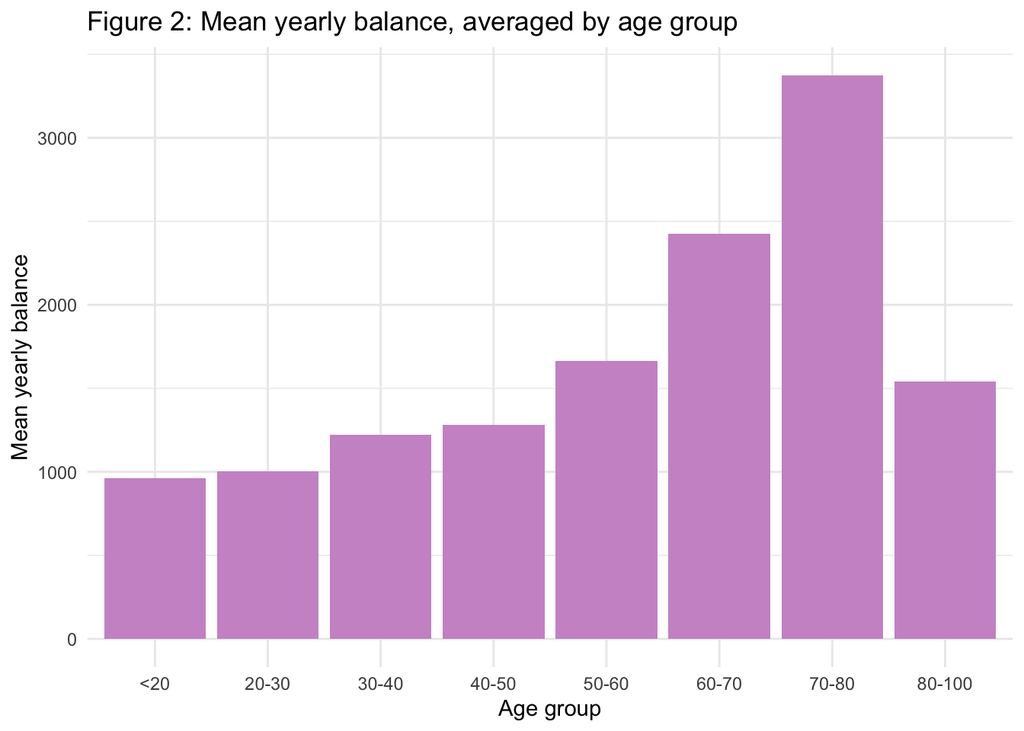

```r
ggplot(data_new, aes( y=mean_balance, x=age_group)) +
    geom_bar(position="dodge", stat="identity",fill = 'plum3') +
  labs(title = 'Figure 2: Mean yearly balance, averaged by age group',
       x = 'Age group',
       y = 'Mean yearly balance') +
  theme_minimal()
```

Figure 3 shows the total number of campaigns by job type for subscribers and non-subscribers. It shows the amount of effort the bank pursued each occupation group. However, this plot may just reflect the number of each job type in the population and sample. Figure 4 shows the average number of campaigns, and we observe that the bank pursued each group by proportionally similar amounts.

```r
# unknown <- c('unknown')
# no_income <- c('unemployed','student')
# low_income <- c('blue-collar','housemaid','retired','self-employed')
# high_income <- c('admin.','entrepreneur','management','services','technician')
# dat_plot <- dat_full
# dat_plot$job<-recode(dat_plot$job,"unknown='unknown'; no_income='no_income';
#                       low_income = 'low_income'; high_income = 'high_income'")

dat_plot = dat.working %>%
  group_by(job, y) %>%
  summarize(avg_campaign = mean(campaign),
            tot_campaign = sum(campaign)) %>%
  ungroup()
```

[output not shown]

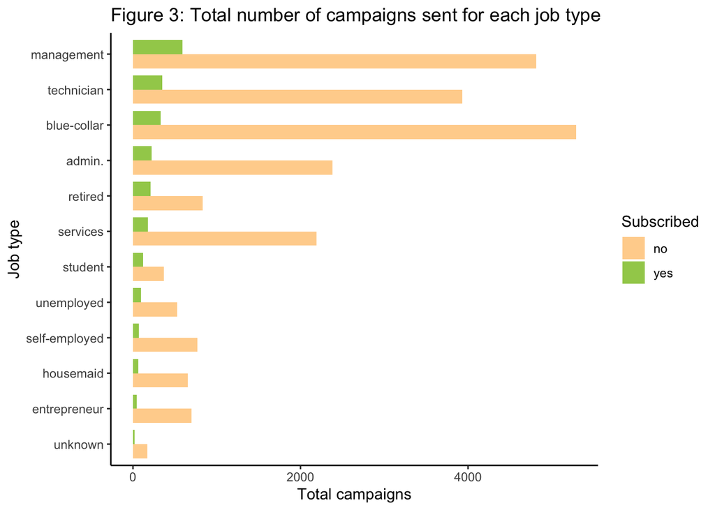

```r
ggplot(dat_plot, aes(fill=y, y=tot_campaign, x=reorder(job, tot_campaign, function(x) x[2]))) +
  geom_bar(position='dodge', stat='identity', width=0.8) +
  theme_classic() +
  labs(fill = "Subscribed",
       title = 'Figure 3: Total number of campaigns sent for each job type',
       y = 'Total campaigns',
       x = 'Job type') +
  coord_flip() +
  scale_fill_manual(values = c("burlywood1","darkolivegreen3"))
```

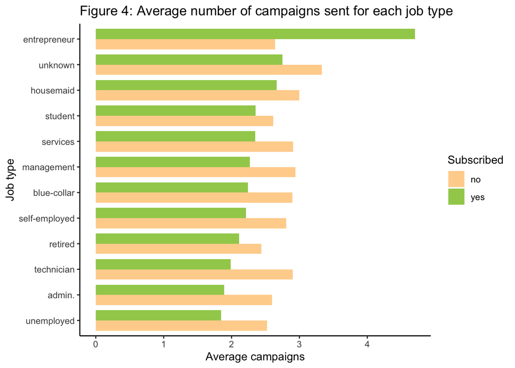

```r
ggplot(dat_plot, aes(fill=y, y=avg_campaign, x=reorder(job, avg_campaign, function(x) x[2]))) +
  geom_bar(position='dodge', stat='identity', width=0.8) +
  theme_classic() +
  labs(fill = "Subscribed",
       title = 'Figure 4: Average number of campaigns sent for each job type',
       y = 'Average campaigns',
       x = 'Job type') +
  coord_flip() +
  scale_fill_manual(values = c("burlywood1","darkolivegreen3"))
```

```r
scale2sd <- function(x) {
  (x - mean(x) )/ (2*sd(x))
}

# put continuous vars on same scale as indicators
# put here b/c want summary table/figures to show on raw scale
dat.working = dat.working %>%
  mutate(age = scale2sd(age),
         campaign = scale2sd(campaign),
         balance = scale2sd(balance),
         previous = scale2sd(previous))

# select training and testing data
set.seed(100)
y <- dat.working$y
index <- createDataPartition(
  y,
  times = 1,
  p = 0.8,
  list = F,
  groups = min(5, length(y))
)
dat_train <- dat.working[index,]
dat_test <- dat.working[-index,]
```

## Methods

### SVM

Support vector machines were chosen for their flexibility and good out-of-box performance for classification. By fitting SVM using both linear and RBF kernels, we allow for flexibility in the relationship between the outcome and features.

We held out 20 percent of the data as a test set for final model performance evaluation. The remaining 80 percent of the data was used as training data to select hyperparameters in the SVM models. We chose F1 score as our final metric for model comparison. F1 score is the harmonic mean of the precision and recall: $F1 = \frac{2(P \cdot R)}{P+R}$, where $P$ is the precision: $\frac{TP}{TP + FP}$, and $R$ is the recall of the classification model: $\frac{TP}{TP + FN}$, where $TP$ is the number of true positives, $FP$ is the number of false positives, and $FN$ is the number of false negatives.

Support vector machines (SVM) [4] are a popular machine learning method for binary classification. SVM classifies observations by separating the feature space into two classes according to some decision boundary form with the goal of maximizing the number of correct classifications while allowing for some mis-classifications for identifiability and to prevent over-fitting. The form of the decision boundary is controlled by choice of the kernel function. We fitted SVM models using linear and radial kernels.

Formally, SVM solves the following Lagrangian dual

$$\begin{equation}
\begin{split}
\max_{\substack{\alpha}} \sum_{i=1}^{n} \alpha_i - \frac{1}{2} \sum_{i, j = 1}^{n} y_i y_j \alpha_i \alpha_j K(x_i, x_j) \\
\text{s.t. } 0 \leq \alpha_i \leq C, i=1,\dots, n \text{ and } \sum_{i=1}^{n} \alpha_i y_i = 0
\end{split}
\end{equation}$$

where $y \in \{-1, 1\}$ are the classification labels, $\alpha$ are the Lagrangian multipliers, $C$ is a tuning parameter chosen by cross-validation, and $K(x, x')$ represents the kernel function. The linear kernel corresponds to the dot product between $x$ and $x'$, and the radial kernel corresponds to $K(x, x') = \exp\left( \gamma ||x-x'||^2 \right)$ where $\gamma$ is a tuning parameter that will be chosen by cross-validation.

Since SVM is not good at handling class imbalance in the sense that it favors the majority class, we performed weighted SVM instead. In our dataset, the majority class are the negatives i.e. $Y=-1$. For the class $Y=-1$, the weight equals $\frac{1}{n} \sum_{i=1}^n I(Y_i=1)$ and for the class $Y=1$, the weight equals $1-\frac{1}{n} \sum_{i=1}^n I(Y_i=1)$. Thus, we down-weighted the majority class and up-weighted the minority class.

We fit SVM using the R packages `e1071` and `WeightSVM`.

### Model evaluation

We used 5-fold cross validation to select tuning parameters for SVM. For SVM, we used both a linear kernel and a radial basis function (RBF) kernel. SVM with a linear kernel contains a penalization hyperparameter $C$, and SVM with an RBF kernel contains a penalization hyperparameter $C$ as well as a tuning parameter $\gamma$ which accounts for the smoothness of the decision boundary and controls the variance of the model. For the linear kernel we test $C=(0.001, 0.01, 0.1, 1, 5)$ and for the RBF kernel we test all combinations of $C=(0.001, 0.01, 0.1, 1)$ and $\gamma=(0.03125, 0.12500, 0.50000, 2.00000)$. The error function to minimize was the mis-classification rate.

```r
# weights for svm
x <- model.matrix(y~., dat_train)[,-1]
x.test <- model.matrix(y~., dat_test)[,-1]
y2 <- ifelse(dat_train$y == "yes", 1, 0)

w = rep(mean(y2), nrow(dat_train))
w = ifelse(y2==1, 1-w, w)

# Linear SVM
if (run_from_scratch) {

  # set seed
  set.seed(100)

  # do CV and select best model
  best.linear = best.tune_wsvm(train.x=x, train.y=dat_train$y, weight=w, ranges=list(cost=c(0.001, 0.01, 0.1, 1, 5)),
                             tunecontrol=tune.control(sampling='cross', cross=5),
                             kernel='linear', scale=FALSE)

  # save
  saveRDS(best.linear, 'cv_sim_lin.rds')

} else {
  best.linear = readRDS('cv_sim_lin.rds')
}

# Radial SVM
if (run_from_scratch) {

  # set seed
  set.seed(100)

  # do CV and select best model
  best.radial = best.tune_wsvm(train.x=x, train.y=dat_train$y, weight=w,
                             ranges=list(cost=c(0.001, 0.01, 0.1, 1),
                                         gamma=2^seq(-5,2,by=2)),
                             tunecontrol=tune.control(sampling='cross', cross=5),
                             kernel='radial', scale=FALSE)

  # save
  saveRDS(best.radial, file = "radial_svm.RDS")

} else {
  best.radial = readRDS('radial_svm.RDS')
}
```

## Results

For the SVM models, the chosen cost hyperparameter for the linear kernel was 0.1, and for the RBF kernel, the chosen cost and $\gamma$ were 1 and 0.125, respectively. The numbers of support vectors are 5215 and 5415, respectively, for linear and kernel SVM.

```r
# train data; svm linear
svm.pred.lin.train <- predict(best.linear)
svm.lin.train.res = confusionMatrix(svm.pred.lin.train, dat_train$y, positive = 'yes')$byClass

# train data; svm radial
svm.pred.rad.train <- predict(best.radial)
svm.rad.train.res = confusionMatrix(svm.pred.rad.train, dat_train$y, positive = 'yes')$byClass

# test data; svm linear
svm.pred.lin.test <- predict(best.linear, x.test)
svm.lin.test.res = confusionMatrix(svm.pred.lin.test, dat_test$y, positive = 'yes')$byClass

# test data; svm radial
svm.pred.rad.test <- predict(best.radial, x.test)
svm.rad.test.res = confusionMatrix(svm.pred.rad.test, dat_test$y, positive = 'yes')$byClass

# put it all into a dataframe
pred_metrics = tibble(Metric = names(svm.lin.train.res),
                      `SVM linear kernel, train` = svm.lin.train.res,
                      `SVM radial kernel, train` = svm.rad.train.res,
                      `SVM linear kernel, test` = svm.lin.test.res,
                      `SVM radial kernel, test` = svm.rad.test.res)
```

```r
# display results
kable(pred_metrics, caption='Table 3',
      digits=3, format='html', row.names=FALSE)
```

Table 3

| Metric | SVM linear kernel, train | SVM radial kernel, train | SVM linear kernel, test | SVM radial kernel, test |
| --- | --- | --- | --- | --- |
| Sensitivity | 0.636 | 0.755 | 0.592 | 0.621 |
| Specificity | 0.795 | 0.804 | 0.778 | 0.782 |
| Pos Pred Value | 0.292 | 0.338 | 0.260 | 0.273 |
| Neg Pred Value | 0.943 | 0.961 | 0.935 | 0.940 |
| Precision | 0.292 | 0.338 | 0.260 | 0.273 |
| Recall | 0.636 | 0.755 | 0.592 | 0.621 |
| F1 | 0.400 | 0.467 | 0.362 | 0.380 |
| Prevalence | 0.117 | 0.117 | 0.117 | 0.117 |
| Detection Rate | 0.074 | 0.088 | 0.069 | 0.072 |
| Detection Prevalence | 0.256 | 0.261 | 0.266 | 0.265 |
| Balanced Accuracy | 0.715 | 0.779 | 0.685 | 0.701 |

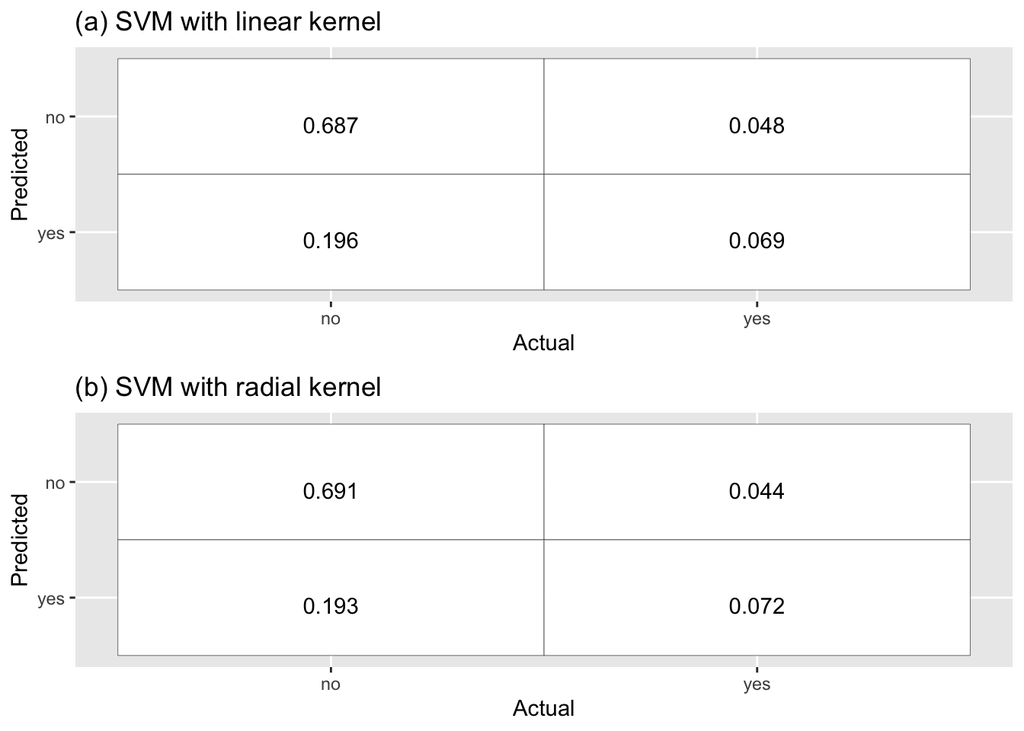

```r
# function to create data frames w/ confusion matrix vals
create_conf_df <- function(pred, actual) {
  dat = data.frame(Predicted = c('no', 'yes', 'no', 'yes'),
                   Actual = c('no', 'no', 'yes', 'yes'),
                   props = c(mean(pred=='no' & actual=='no'),
                             mean(pred=='yes' & actual=='no'),
                             mean(pred=='no' & actual=='yes'),
                             mean(pred=='yes' & actual=='yes')))
  dat$props = round(dat$props, 3)
  return(dat)
}

# create confusion matrix df for each model on test data
conf.svm.lin = create_conf_df(svm.pred.lin.test, dat_test$y)
conf.svm.rad = create_conf_df(svm.pred.rad.test, dat_test$y)

# create ggplot objects
gg.svm.lin = ggplot(data =  conf.svm.lin, mapping = aes(x = Actual, y = Predicted)) +
  geom_tile(colour = "black", fill='white') +
  geom_text(aes(label = props), vjust = 1) +
  theme(legend.position = "none") +
  labs(title = '(a) SVM with linear kernel') +
  scale_y_discrete(limits=rev)

gg.svm.rad = ggplot(data =  conf.svm.rad, mapping = aes(x = Actual, y = Predicted)) +
  geom_tile(colour = "black", fill='white') +
  geom_text(aes(label = props), vjust = 1) +
  theme(legend.position = "none") +
  labs(title = '(b) SVM with radial kernel') +
  scale_y_discrete(limits=rev)

# plot
grid.arrange(gg.svm.lin, gg.svm.rad, nrow=2)
```

Table 3 shows all the model performance evaluation metrics using the two methods on training and testing datasets, and Figure 7 shows the confusion matrices for the predictions of each method on the testing dataset.

From Table 3, we can see that the test set F1 score for linear kernel SVM and radial kernel SVM are similar (0.362 and 0.380, respectively). Examining the confusion matrices in Figure 7 shows that the predictions of each method were similar as well. Radial SVM correctly predicted slightly more observations. Overall, radial SVM had higher sensitivity (0.621 vs. 0.592) and specificity (0.782 vs. 0.778) on testing set.

## Discussion

For example, if we imagine that the bank under study desired a prediction tool which could screen out individuals who were very unlikely to subscribe a term deposit. In this case, they would want to minimize the number of false negatives while maximizing the number of true negatives. Equivalently, this would mean maximizing the negative predictive value. We could also imagine the bank wanting a small list of clients to target but also wanting to not leave out any individuals who would actually subscribe a term deposit. Then, this would be equivalent to maximizing sensitivity, or the ratio of true positives to false negatives.

Finally, we note two limitations of any prediction model using this dataset. First, applying models based on historical data to future populations requires an assumption of transportability. If the future population is substantially different from the historical population the model is based on, in the sense that their relationship to the outcome variable has changed, then that would limit the applicability of the model. For example, consider if this data was collected during a period of general confidence in banks and financial systems. Now imagine an event happens after the data is collected such as a recession or banking failure which reduces confidence in banks for many individuals. If confidence in banks is important for whether or not an individuals subscribes a term deposit, and if there is no way to predict this variable, then models trained on the historical data would have limited utility.

Second, we note the limitation that the outcome variable is binary, when in practice, it is likely that banks would care about the amount which an individual deposits.

## References

1. Marshall JJ, Vredenburg H. Successfully using telemarketing in industrial sales. Industrial Marketing Management. 1988;17:15–22.

2. Moro S, Cortez P, Rita P. A data-driven approach to predict the success of bank telemarketing. Decision Support Systems. 2014;62:22–31.

3. Gelman A. Scaling regression inputs by dividing by two standard deviations. Statistics in Medicine. 2008;27:2865–73.

4. Cortes C, Vapnik V. Support-vector networks. Machine learning. 1995;20:273–97.